# Curriculum Vitae

Download a PDF copy

## **Education & Research Experience**

#### **National Institute of Standards & Technology / University of Maryland, College Park**

- **June 2026 - present**: Postdoctoral researcher in the [Butch Lab](https://sites.google.com/site/npbutch/group), affiliated with both the [NIST Center for Neutron Research](https://www.nist.gov/ncnr) and [UMD Physics](https://umdphysics.umd.edu/). Working on a variety of projects including an optimized synthetic method for UTe2 and a topotactic B-site reduction method to induce magnetism in nonmagnetic rare earth pyrochlores.

#### **Johns Hopkins University**

- **Nov. 2019 – Aug. 2025**: Graduate research in the [McQueen Lab](https://occamy.chemistry.jhu.edu/) on synthesis and characterization of doped Ising-like A2B2O6O’ rare earth pyrochlores for comparison to quantum annealer simulations. Additional project on identifying and quantifying defects in spin-qubit candidate host materials Ba/Sr2CaWO6.
- **Aug. 2025**: PhD in Chemistry  
  Thesis title: “A Systematic Investigation of Defects in Quantum Materials” (available [online at JScholarship](https://jscholarship.library.jhu.edu/handle/1774.2/71426))
- **Aug. 2021**: M.A. in Chemistry
- Advisor: [Tyrel M. McQueen](https://occamy.chemistry.jhu.edu/group/boss-cv.php)

#### **McDaniel College**

- **May 2019**: B.A., Physics and Chemistry with a minor in Mathematics, *magna cum laude*
- **June – July 2017**: Undergraduate research in the [Pagonis lab](https://web.archive.org/web/20231130141144/https://blog.mcdaniel.edu/vasilispagonis/) on Monte Carlo modelling of electron tunneling in geological material and its effect on thermoluminescence rates.
- Addtl. advisors: [Apollo Mian](https://www.mcdaniel.edu/about-us/profiles/apollo-mian-phd) and [Dana Ferraris](https://www.mcdaniel.edu/directory/dana-ferraris)

#### **National Institute of Standards and Technology**

- **May - Aug. 2018**: Summer undergraduate research fellowship ([SURF](https://www.nist.gov/surf)) in the [Materials Measurement Laboratory](https://www.nist.gov/mml) developing a machine learning thermochemical analysis method for biofuel blends using a device called the laser-driven thermal reactor.
- Advisors: [Cary Presser](https://www.nist.gov/people/cary-presser) and [Ashot Nazarian](https://www.nist.gov/people/ashot-nazarian)

## Publications

- “Order-Disorder Transitions In Yb2Ti2O7 and Their Effects on Material Color” by Bernier et. al. *In Preparation* **2026**.
- “A Crystallographic Metric for Continuous Quantification of Unit Cell Deformation” by Bernier et. al. *In Preparation* **2026**. An early draft is available on the ArXiv: [2508.01177v1](https://doi.org/10.48550/arXiv.2508.01177)

  **View abstract**

  Describing the deviation of a real structure from a hypothetical higher-symmetry ideal can be a powerful tool to understand and interpret phase transitions. Here we introduce a simple yet effective metric that quantifies the degree of unit cell distortion relative to a cube, called the cubic deviation metric. This enables continuous comparisons between unit cells of different geometries. We demonstrate the potential of this tool with four separate case study applications to real material systems: 1) discontinuous structural phase transitions in pseudobrookites; 2) homological structure classification; 3) structure-correlated piezoelectricity in hexagonal materials; and 4) superconducting materials design in the cuprate family. Although this metric does not replace detailed structural or group theory analysis, it enables comparison across different compositional and structural compound variants, even in the presence of disorder or absence of group–subgroup correlation.
- “Symmetry-mediated quantum coherence of W5+ spins in an oxygen-deficient double perovskite” by Bernier et. al. *npj Quantum Materials* **2025**. DOI: 10.1038/s41535-025-00782-3

  **View abstract**

  Elucidating the factors limiting quantum coherence in real materials is essential to the development of quantum technologies. Here we report a strategic approach to determine the effect of lattice dynamics on spin coherence lifetimes using oxygen deficient double perovskites as host materials. In addition to obtaining millisecond $T_1$ spin-lattice lifetimes at T ~ 10 K, measurable quantum superpositions were observed up to room temperature. We determine that $T_2$ enhancement in $Sr_2CaWO_{6-δ}$ over previously studied $Ba_2CaWO_{6-δ}$ is caused by a dynamically-driven increase in effective site symmetry around the dominant paramagnetic site, assigned as $W^{5+}$ via electron paramagnetic resonance spectroscopy. Further, a combination of experimental and computational techniques enabled quantification of the relative strength of spin-phonon coupling of each phonon mode. This analysis demonstrates the effect of thermodynamics and site symmetry on the spin lifetimes of $W^{5+}$ paramagnetic defects, an important step in the process of reducing decoherence to produce longer-lived qubits.
- “Random-exchange Heisenberg behavior in the electron-doped quasi-one-dimensional spin-1 chain compound AgVP2S6” by Orban et. al. *Phys. Rev. B.* **2024** DOI: 10.1103/PhysRevB.110.054423

  **View abstract**

  Recent theoretical work suggests that a pair-density wave superconducting state can be realized by doping a one-dimensional spin-1 chain. Here, we report the physical properties of single crystals of $Mg_x Ag_{1−x}VP_2S_6$ [x = 0, x = 0.017(6), x = 0.067(8), and 0.098(11)] prepared by solid-state synthesis. Single-crystal x-ray-diffraction measurements confirm that Mg2+ is substituting for Ag+ to electron dope the V 3+ zigzag chains. Magnetization measurements reveal that electron doping breaks up the V 3+ chains, resulting in unpaired spins at the chain ends. The $Mg_x Ag_{1−x}VP_2S_6$ series is consistent with random-exchange Heisenberg antiferromagnetic chain behavior and can be well described by the exchange-coupled pair model at low temperatures. Transport measurements show $Mg_x Ag_{1−x}VP_2S_6$ remains insulating in the range 0 < x <= 0.098(11), with the band gap decreasing to ∼ 0.2 eV at x = 0.098(11).
- “Disordered Layers and Dimerization in the Crystal Structure of TaOCl2” by Ng et. al. *J. Solid State Chem.*, **2024**. DOI: 10.1016/j.jssc.2024.124771

  **View abstract**

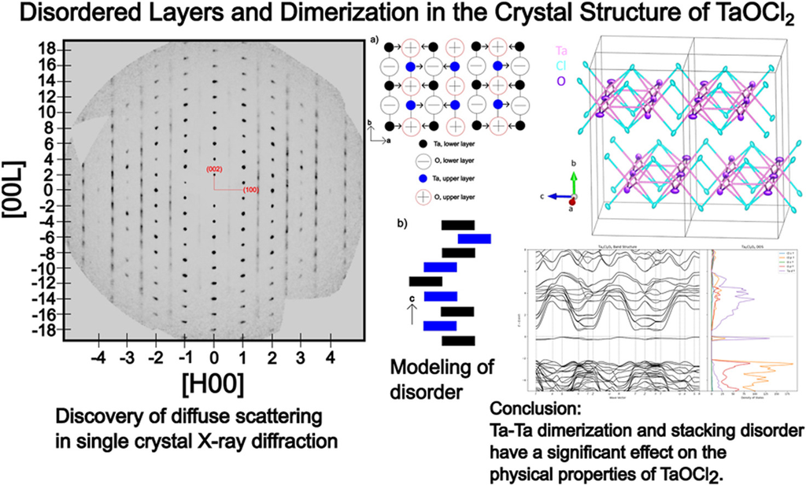

  Understanding the properties of transition metal materials requires consideration of the competition between the various types of electrons that comprise the system, whether they be delocalized and metallic, localized and magnetic, or localized and bonded. Here we report the refined crystal structure determination and physical properties of the two-dimensional layered compound TaOCl2. Within each layer we find a strong in-plane dimerization of Ta atoms perpendicular to the Ta-O-Ta chains, with significant disorder in the positioning of dimers in adjacent layers, suggesting that the free electron of each Ta localizes in Ta-Ta bonds. This is supported by resistivity measurements (ρ300K = 4.4*108 Ω-cm) as well as featureless, temperature-independent magnetic susceptibility up to T = 750 K. Analysis of the phonon contribution to specific heat shows the presence of a localized Einstein mode with TE = 175 K, attributed to the localized vibrations of the Ta-Ta dimers. Density functional theory calculations show that the magnitude of the Ta displacements (0.24 Å) has a dramatic effect on the electronic structure, changing from a metal with a bandwidth of 3.2 eV to an insulator with a flat band just below EF. Our results show how direct exchange interactions between Ta atoms that are relatively far from each other can still play a central role in the behavior of 5d transition metal compounds, taking advantage of the extended 5d atomic orbitals, and produce localized dimers with a bond distance of approximately 2.84 Å.
- “Tunable W5+ Absorbance in Laser Floating Zone Grown Bismuth Tungstate” by Pressley et. al. *J. Phys. Chem C.*, **2023**. DOI: 10.1021/acs.jpcc.3c04645

  **View abstract**

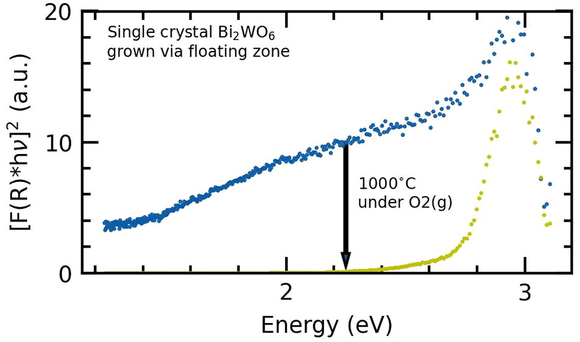

  Bi2WO6 has been actively investigated as a viable photocatalysis substitute for TiO2. This along with progress in designing qubit hosts using W5+ centers encourages the development of single crystal growths of this material using the floating zone technique. Single crystals of Bi2WO6–x were grown using a laser diode floating zone furnace. Laue diffraction and single crystal X-ray diffraction confirm development of single crystalline domains. Williamson–Hall analysis shows annealed floating zone crystals contain less strain compared to unannealed and flux grown samples. Fitting of the heat capacity data shows two optical phonon modes modeled by Einstein oscillators, with the lower energy oscillator decreasing post annealing. The band gap is estimated as 2.6 eV using hyperspectral imaging, showing an additional absorption band present in the oxygen-deficient samples compared to those grown via flux. This additional absorption is tunable via annealing post growth. Overall, this technique demonstrates the feasibility of growing large single crystals of Bi2WO6 with tunable W5+ centers for potential application in photocatalysis and quantum information.
- “Laser floating zone growth of SrVO3 single crystals” by Berry et. al. *Journal of Crystal Growth*, **2022**. DOI: 10.1016/j.jcrysgro.2022.126518

  **View abstract**

  The perovskite SrVO3 is of interest for a variety of applications due to its simple metallic character and stability in reducing environments. Here we report the preparation of single-crystal SrVO3 using the laser floating zone technique. Laue diffraction implies single domains ∼30 mm in length. The stoichiometry of optimized crystals was found to be Sr0.985(7)VO2.91(4) using inductively coupled plasma optical emission spectrometry and neutron powder diffraction analysis, with compositions adjustable with crystal pulling rate. Heat capacity measurements from T = 2 – 300 K show variations with composition, attributable to a combination of impurity scattering and changes in phonon dynamics. Our results demonstrate the utility of the laser floating zone technique in preparing a range of materials, and our advances with SrVO3 may help lead to applications including catalysis, transparent conducting oxides, thermionic emitters, and other electronic devices.
- “Laser-Driven Calorimetry and Chemometric Quantification of Standard Reference Material Diesel/Biodiesel Fuel Blends” by Presser et. al., *Fuel*, **2020**. DOI: 10.1016/j.fuel.2020.118720

  **View abstract**

  Requirements for blends of drop-in petroleum/bio-derived fuels with specific thermophysical and thermochemical properties highlights the need for chemometric models that can predict these properties. Multivariate calibration methods were evaluated using the measured thermograms (i.e., change in temperature with time) of 11 diesel/biodiesel fuel blends (including four repeated runs for each fuel blend). Two National Institute of Standards and Technology Standard Reference Material® (SRM®) pure fuels were blended by serial dilution to produce fuels having diesel/biodiesel volumetric fractions between (0 to 100) %. The fuels were evaluated for the prepared fuel-blend volume fraction and total specific energy release (heating value), using a laser-driven calorimetry technique, termed ‘laser-driven thermal reactor’. The experimental apparatus consists of a copper sphere-shaped reactor (mounted at the center of a stainless-steel chamber) that is heated by a high-power continuous wave Nd:YAG laser. Prior to heating by the laser, liquid sample is injected onto a copper pan substrate that rests near the center of the reactor and is in contact with a fine-wire thermocouple. A second thermocouple is in contact with the sphere-reactor inner surface. The thermograms are then used to evaluate for the thermochemical characteristic of interest. Partial least squares (PLS) and support vector machine (SVM) models were constructed and evaluated for SRM-fuel-blend quantification, and determination of prepared fuel-blend volume fraction and heating value. Quantification of the fuel-blend thermograms by the SVM method was found to better correlate with the experimental results than PLS. The combination of laser-driven calorimetry and multivariate calibration methods has demonstrated the potential application of using thermograms for fuels quantification and analysis of fuel-blend properties.
- “The effect of crystal size on tunneling phenomena in luminescent nanodosimetric materials” by Pagonis et. al., *Nuc. Inst. & Methods B*, **2017**. DOI: 10.1016/j.nimb.2017.09.016

  **View abstract**

  The study of luminescence signals from nanodosimetric materials is an active research area, due to the many possible practical applications of such materials. In several of these materials it has been shown that quantum tunneling is a dominant mechanism for recombination processes associated with luminescence phenomena. This paper examines the effect of crystal size on quantum tunneling phenomena in nanocrystals, based on the assumption of a random distribution of electrons and positive ions. The behavior of such random distributions is determined by three characteristic lengths: the radius of the crystal R, the tunneling length a, and the initial average distance 〈d〉 between electrons and positive ions (which is directly related to the density of charges in the material). Two different cases are examined, depending on the relative concentrations of electrons and ions. In the first case the concentration of electrons is assumed to be much smaller than the concentration of positive ions. Examination of a previously derived analytical equation demonstrates two different types of crystal size effects. When the tunneling length a is much smaller than both R and 〈d〉, the analytical equations show that smaller crystals exhibit a faster tunneling recombination rate. However, when the tunneling length a is of the same order of magnitude as both R and 〈d〉, the opposite effect is observed, with smaller crystals exhibiting a slower tunneling recombination rate. As the crystal size increases, the rate of tunneling in both cases reaches the limit expected for bulk materials. In the second case we examine the situation where the concentrations of electrons and positive ions are equal at all times. In this situation there is no analytical equation available to describe the process, and the crystal size effects are simulated by using Monte Carlo (MC) techniques. The two opposite behaviors as a function of the crystal size are also observed in these MC simulations. The effect of sample temperature is also studied by extending the MC simulations to include thermal characteristics of the defects. The relevance of the simulated results for luminescence dosimetry is discussed.

## Presentations

- **Apr. 2025** [Materials Research Society Spring Meeting](https://www.mrs.org/meetings-events/annual-meetings/2025-mrs-spring-meeting) Seattle, WA; poster.
- **Sept. 2024** [National QIS Research Centers PI Meeting](https://web.cvent.com/event/926eb48e-6cd9-4395-b1dd-9400d6af06a8/summary) Rockville, MD; poster.
- **Feb. 2024** Aspen Center for Physics Conference: [Quantum Materials in the Quantum Information Era: From Theory to Experiment](https://sites.google.com/view/acp-winter-2024-quantum/home) Aspen, CO; poster.
- **Oct. 2023** Co-Design Center for Quantum Advantage [All-Hands Meeting](https://www.bnl.gov/c2qaallhandsmeeting/events/), virtual; [poster](https://www.researchgate.net/publication/374504697_Understanding_material-specific_sources_of_quantum_decoherence).
- **Oct. 2022** Co-Design Center for Quantum Advantage [All-Hands Meeting](https://www.bnl.gov/c2qaallhandsmeeting/events/) New Haven, CT; poster.
- **Apr. 2019** Northeast Regional Honors Council Annual Conference: [Generating Power](https://www.nrhchonors.com/_files/ugd/7b5b51_48995395639b411987e0bf586003c98d.pdf) Baltimore, MD; oral presentation. Received “Best Presentation” award in the Alternative Energy category.
- **Mar. 2019** Maryland Collegiate Honors Conference: [Conflict and Resolution](https://mdhonorscouncil.weebly.com/2019-conference.html) Morgan State University – Baltimore, MD; poster. Received “Best Poster” award.
- **Oct. 2018** [Undergraduate Research Conference in the Chemical & Biological Sciences](https://cnmssymposium.umbc.edu/wp-content/uploads/sites/170/2018/10/2018-URS-Abstract-Book_Online.pdf) University of Maryland Baltimore County – Baltimore, MD (Oct. 2018); poster.
- **Mar. 2018** Maryland Collegiate Honors Conference: [Taking Action](https://mdhonorscouncil.weebly.com/2018-conference.html) Frostburg State University – Frostburg, MD; poster.

## **Teaching & Teacher Training**

#### **Adjunct Chemistry Instructor**

**Dec. 2025 – Present** Frederick Community College – Frederick, MD  
- Instructor for two sections of General Chemistry I lecture & lab.

#### **Johns Hopkins University Teaching Academy [Certificate of Completion](https://teachingacademy.jhu.edu/certificates/)**

**Dec. 2022** Johns Hopkins University – Baltimore, MD  
- Relevant coursework: JHU 3-day [Teaching Institute](https://teachingacademy.jhu.edu/training/teaching-institute/), [CIRTL](https://cirtl.net/) “An Introduction to Evidence-Based Undergraduate STEM Teaching”, CIRTL “Introduction to Teaching at a Community College”, CIRTL “Incorporating Scientific Communication into STEM Courses”.  
- Independent teaching requirement satisfied by teaching 10-hour module about LabVIEW to Data Science Tools for the Chemical and Materials Sciences undergraduate course. Mentored by Tyrel McQueen.

#### **Gymnastics Instructor**

**Nov. 2014 – Present** Frederick Gymnastics Club – Frederick, MD  
- Design and implement curricula, give safety lectures, and work as substitute instructor for recreational gymnastics and tumbling. Specialize in boys’ and girls’ tumbling and acrobatics, ages 6-18.  
- USAG certified [Recreational Coach](https://usagym.org/membership/join/recreational-coach/). SafeSport trained.  
- Adult and Pediatric CPR certified by the American Heart Association (Apr. 2026)

#### **Physical Chemistry Lab Teaching Assistant**

**Sept. 2019 – Dec. 2021** Johns Hopkins University – Baltimore, MD  
- Responsible for operating 1-2 experiments per semester including maintenance of equipment, instruction, safety monitoring, rubric design, and grading. One semester of this lab-based course was taught virtually.

#### **Introductory Chemistry II Head Teaching Assistant**

**Jan. – June 2021** Johns Hopkins University – Baltimore, MD  
- Responsible for exam design, general course logistics, organization of TAs and review material, and communication with students. This course was taught virtually.  
- Experience uploading and formatting course materials (including exams and multimedia files) on Blackboard, Gradescope, Canvas, and Sapling.

#### **Chemistry Laboratory Teaching Assistant**

**Sept. 2017 – May 2019** McDaniel College – Westminster, MD  
- Teaching assistant for individual semesters of Physical Chemistry, Biochemistry I, and Introductory Chemistry labs. Advisors: [Melanie Nilsson](https://www.mcdaniel.edu/directory/melanie-nilsson) and [Stephanie Bettis-Homan](https://www.mcdaniel.edu/directory/stephanie-homan).  
- Responsible for preparing lab materials and equipment and troubleshooting issues during experiments. Assisted with exam proctoring and safety monitoring.

## **Volunteer work**

#### **Chemistry Student Safety Committee**

**May 2022 – May 2024** Johns Hopkins University – Baltimore, MD  
- Instrumental in organizing [first](https://sites.krieger.jhu.edu/chemssc/initiatives/safety-day-22/) and [second annual departmental Safety Days](https://sites.krieger.jhu.edu/chemssc/initiatives/safety-day-2023/) and implementing new labcoat laundering program for the Chemistry Department.  
- Vice Chair Sept. 2022 – Sept. 2023

#### **Volunteer Event Proctor**

**November 2015 – Present** Maryland [Science Olympiad](https://www.soinc.org/)  
- Write, proctor, and grade exams and build events for middle- and high school-level competitions across Maryland.

## Honors and Awards

- **July 2022** Maryland State Arts Council [Folklife Apprenticeship Grant](https://msac.org/programs/maryland-traditions/folklife-apprenticeship) with master artist Linda Van Hart of [Toll House Studio](https://www.tollhousestudio.com/). Watch a [summary video of the project](https://www.youtube.com/watch?v=MBt3PvDMr4c).
- **Apr. 2020** JHU Krieger School of Arts & Sciences Excellence in Teaching Award nominee
- **Apr. 2019** Phi Beta Kappa
- **May 2018** Harry Clary Jones Scholarship for excellence in Chemistry